# Predicting Breast Cancer using Logistic Regression, Decision Trees, and Naïve Bayes

Hugo Argueta, Karina Pizano, Yarely Chino

May 12, 2017

## Introduction

#### *We wanted to predict the presence of breast cancer with an accuracy of at least 85%, based on features that describe characteristics of cancer cell nuclei present in an image.*

### Load data

```r
> set.seed(135)
>
> dat = read.csv("/Users/juice/Documents/CST463/final-project/breast-cancer-prediction/data.csv")
> dat$X = NULL
> dat$output = ifelse(dat$diagnosis == "M", 1, 0)
>
> # Create Factors
> dat$diagnosis = factor(dat$diagnosis, labels =c("None", "Cancer"))
```

### Split dataset into training set and testing set

```r
> num_tr = sample(1:nrow(dat), floor(nrow(dat) * .75))
> tr_dat = dat[num_tr,]
> te_dat = dat[-num_tr,]
```

### Data Exploration

*Scatter plots to detect any correlation between the features. We see strong positive trends between radius mean and perimeter mean, as well as perimeter mean and concavity mean.*

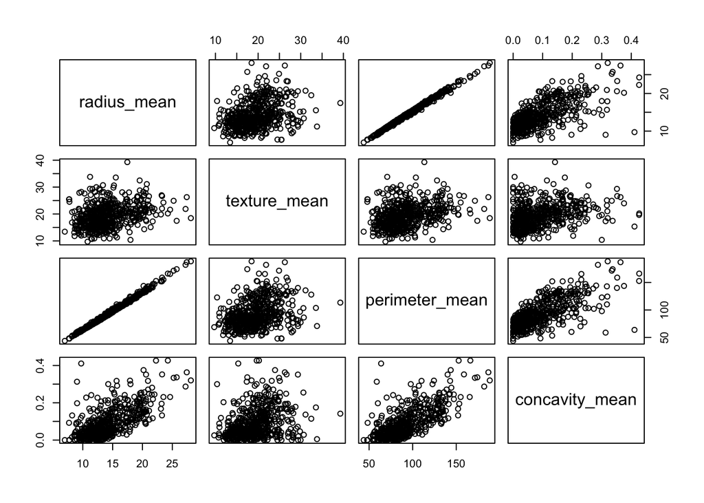

```r
> plot(dat[,c("radius_mean", "texture_mean","perimeter_mean", "concavity_mean")])
```

*Our dataset contains a good balance of diagnosis data.*

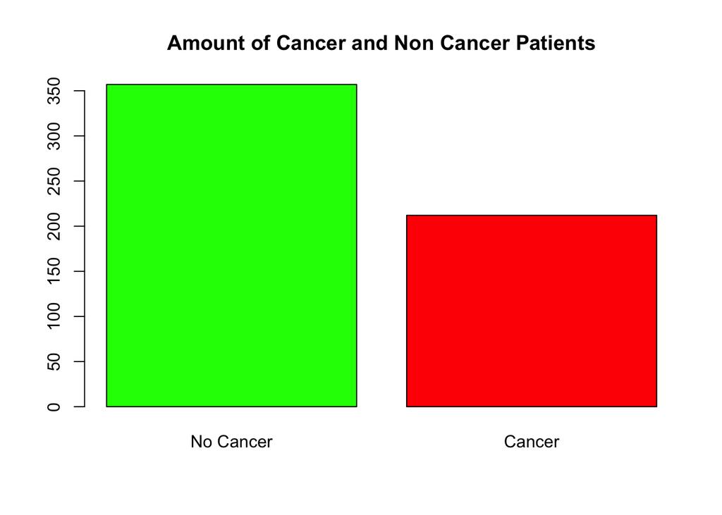

```r
> barplot(table(dat$diagnosis), names.arg=c("No Cancer", "Cancer"), main="Amount of Cancer and Non Cancer Patients", col=c("green", "red"))
```

*Function to predict breast cancer using a single element.*

```r
> predict_by = function(name){
+   plot(dat$output ~ dat$element, col="red", pch = 16, ylab = "probability", xlab = name, main=paste0("Breast cancer probability using ", name))
+   fit = glm(output ~ element, data=dat, family=binomial )
+   bp = data.frame(element=seq(range(dat$element)[1],range(dat$element)[2], length.out=50))
+   probs = predict(fit, newdata=bp, type="response")
+   lines(bp$element, probs, lty=2, col = "green")
+ }
```

#### Logistic function using radius worst

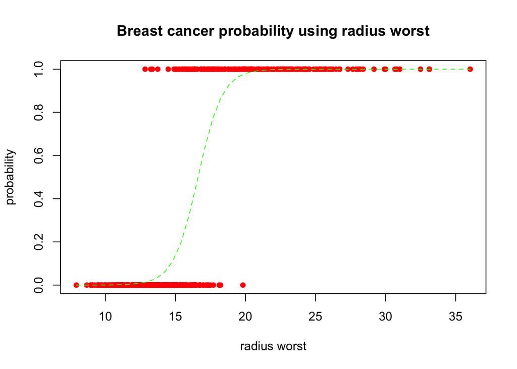

```r
> dat$element = dat$radius_worst
> predict_by("radius worst")
```

#### Logistic function using area standard error

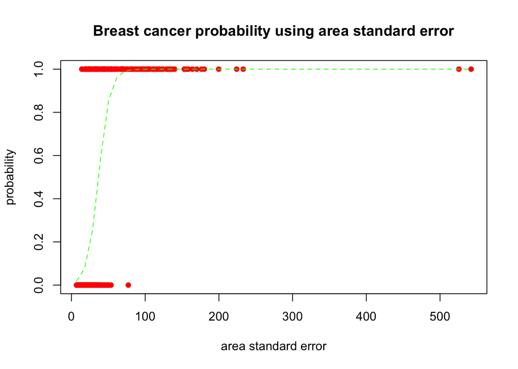

```r
> dat$element = dat$area_se
> predict_by("area standard error")
```

*Here, we are plotting texture worst by radius worst and displaying the occurrences of breast cancer in red, and the occurrences of no breast cancer in green, for each point in our plot. This plot shows that there is a boundary line at around 16. This indicates that these two features will be useful in predicting breast cancer.*

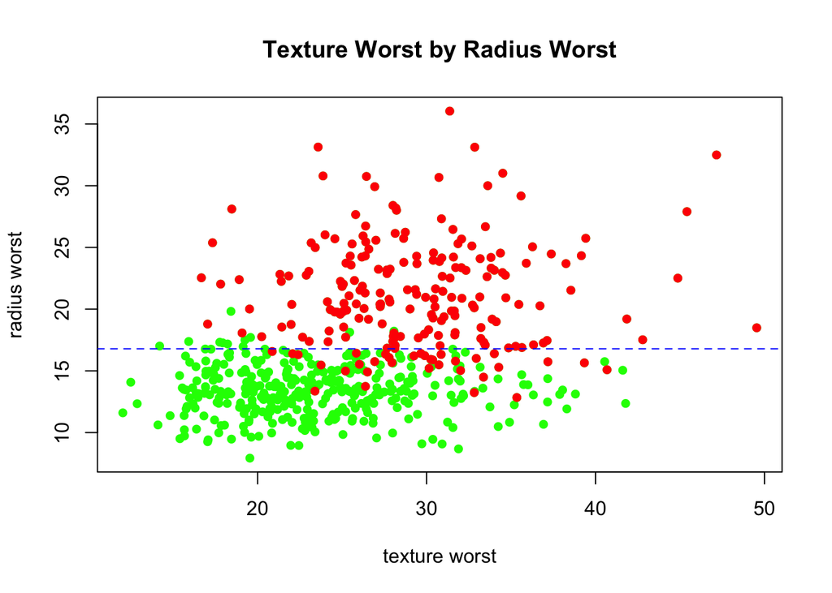

```r
> plot(dat$texture_worst, dat$radius_worst, col = "green", main = "Texture Worst by Radius Worst", xlab = "texture worst", ylab = "radius worst", pch=16)
> malignant = dat$diagnosis == "Cancer"
> points(dat[malignant, ]$texture_worst, dat[malignant, ]$radius_worst, col = "red", pch=16)
> text_rad_fit = rpart(diagnosis ~ texture_worst + radius_worst, data=tr_dat, method="class")
> split = text_rad_fit$splits[1, "index"]
> abline(h=split, lty=2, col='blue')
```

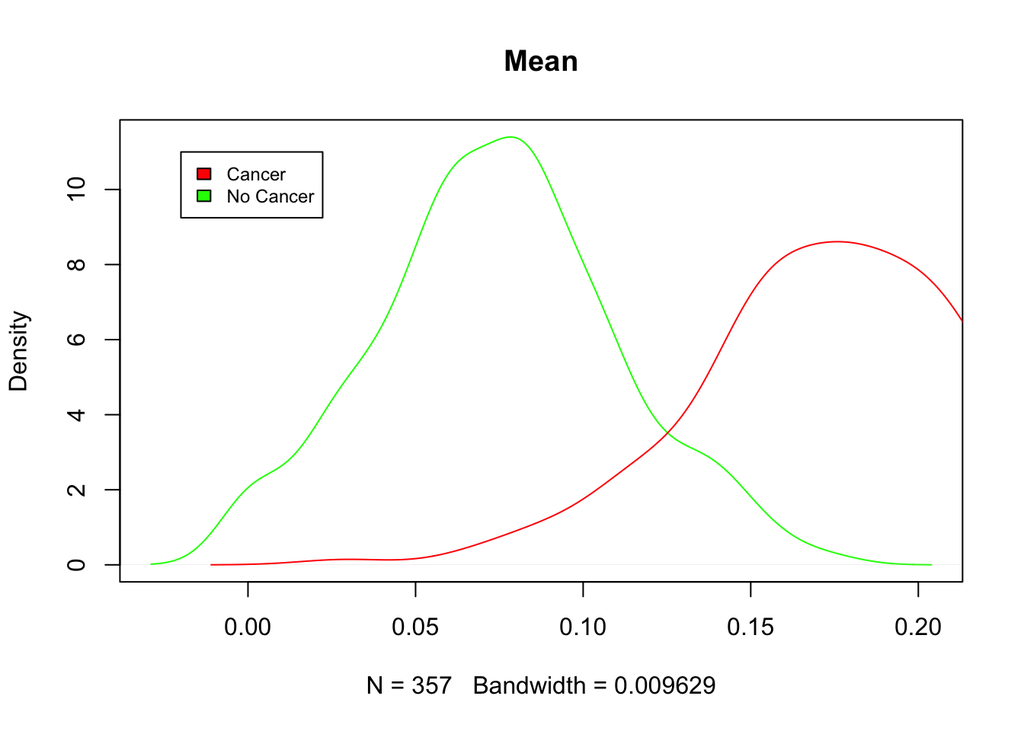

```r
> plot(density(dat[dat$diagnosis == "None",]$concave.points_worst), col="green", main="Mean")
> lines(density(dat[dat$diagnosis == "Cancer",]$concave.points_worst), col="red")
> legend(-.02,11,legend =c("Cancer", "No Cancer"), fill=c("red", "green"), cex=0.75)
```

### Model Creation

#### Creating Logistic Regression

*We are creating a logistic regression model using radius worst, area worst, and smoothness worst in order to predict breast cancer.*

```r
> logistic_fit = glm(output ~ radius_worst + area_worst + smoothness_worst, dat=tr_dat, family=binomial)
```

#### Creating Decision Tree Classifier

*We are creating a decision tree classifier to predict the diagnosis feature based on the features radius worst, concave.points worst, and texture worst.*

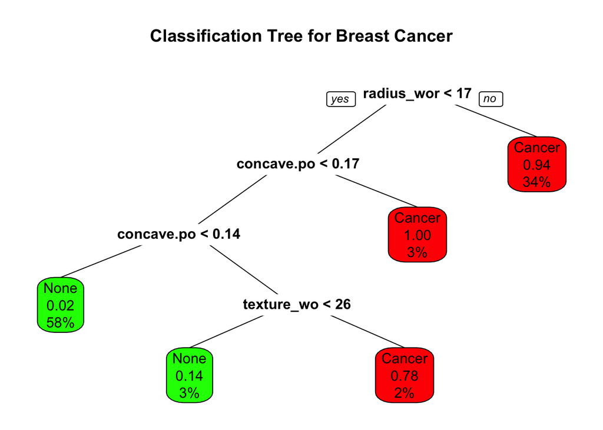

```r
> tree_fit = rpart(diagnosis ~ radius_worst + concave.points_worst + texture_worst, data=tr_dat, method="class")
>
> prp(tree_fit, extra=106, varlen=-10, main="Classification Tree for Breast Cancer", box.col=c("green", "red")[tree_fit$frame$yval])
```

#### Creating Naïve Bayes Classifier

*We are creating a Naïve Bayes classifier to predict the diagnosis feature based on the features radius worst, texture worst, and concave.points worst.*

```r
> bayes_fit = naiveBayes(diagnosis ~ radius_worst + texture_worst + concave.points_worst, data= tr_dat)
```

### Assessing the Models

#### Confusion matrix for Logistic Regression

*From the confusion matrix for actuals vs. predicted, we can see that we have low false positives and low false negatives.*

```r
> pred = predict(logistic_fit, newdata=te_dat, type="response")
> predicts = as.numeric(pred > 0.5)
> actuals = te_dat$output
> conf_mtx = table(predicts, actuals)
> row.names(conf_mtx) = c("B", "M")
> colnames(conf_mtx) = c("B", "M")
> conf_mtx
```

```
        actuals
predicts  B  M
       B 90  3
       M  2 48
```

#### Confusion matrix for Decision Tree

*From the confusion matrix for actuals vs. predicted, we can see that we have low false positives and no false negatives.*

```r
> tree_predicts = predict(tree_fit, te_dat, type="class")
> tree_actuals = te_dat$diagnosis
> tree_conf_mtx = table(tree_actuals, tree_predicts)
> row.names(tree_conf_mtx) = c("B", "M")
> tree_conf_mtx
```

```
            tree_predicts
tree_actuals None Cancer
           B   87      5
           M    0     51
```

#### Confusion matrix for Naïve Bayes

*From the confusion matrix for actuals vs. predicted, we can see that we also have low false positives and low false negatives.*

```r
> bayes_predicts = predict(bayes_fit, te_dat)
> bayes_actuals = te_dat$diagnosis
>
> bayes_conf_mtx = table(bayes_actuals, bayes_predicts)
> row.names(bayes_conf_mtx) = c("B", "M")
> bayes_conf_mtx
```

```
             bayes_predicts
bayes_actuals None Cancer
            B   91      1
            M    2     49
```

### Accuracy of our Classifiers

*Logistic Regression*

```r
> round(mean(predicts == actuals), 3)
```

```
[1] 0.965
```

*Tree Classifier*

```r
> round(mean(tree_predicts == tree_actuals), 3)
```

```
[1] 0.965
```

*Naive Bayes Classifier*

```r
> accuracy = round(mean(bayes_predicts == te_dat$diagnosis), 3)
> accuracy
```

```
[1] 0.979
```

### Precision of our Classifiers

```r
> conf_mtx[2,2] / (conf_mtx[2,2] + conf_mtx[1,2])
```

```
[1] 0.9411765
```

*Tree Classification*

```r
> tree_conf_mtx[2,2] / (tree_conf_mtx[2,2] + tree_conf_mtx[1,2])
```

```
[1] 0.9107143
```

*Naive Bayes*

```r
> bayes_conf_mtx[2,2] / (bayes_conf_mtx[2,2] + bayes_conf_mtx[1,2])
```

```
[1] 0.98
```

### Recall of our Classifier

```r
> conf_mtx[2,2] / (conf_mtx[2,2] + conf_mtx[2,1])
```

```
[1] 0.96
```

*Tree Classification*

```r
> tree_conf_mtx[2,2] / (tree_conf_mtx[2,2] + tree_conf_mtx[2,1])
```

```
[1] 1
```

*Naive Bayes*

```r
> bayes_conf_mtx[2,2] / (bayes_conf_mtx[2,2] + bayes_conf_mtx[2,1])
```

```
[1] 0.9607843
```

### Learning Curves for Classifiers

#### Logistic Regression

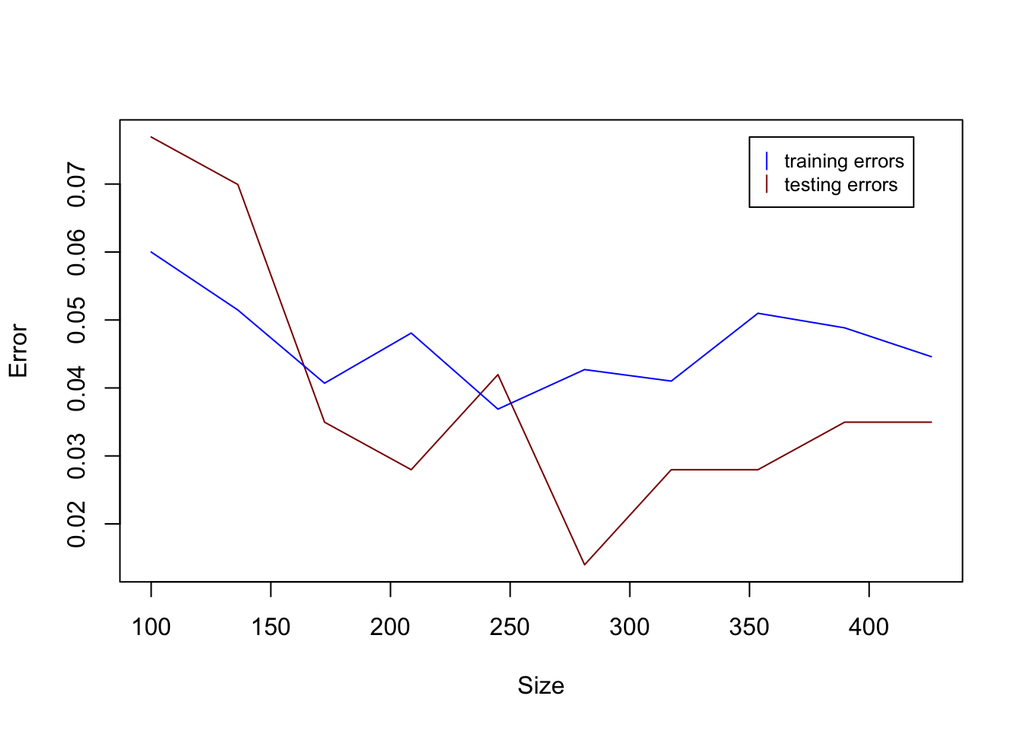

#### Decision Tree Classification

*From this learning curve, we can see that this classifier has low bias and low variance because the training errors and the test error lines converge as the training set size increases.*

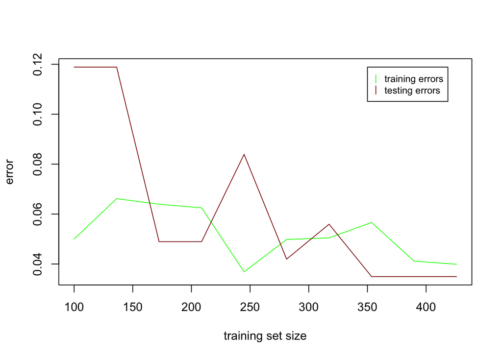

#### Naive Bayes Classifier

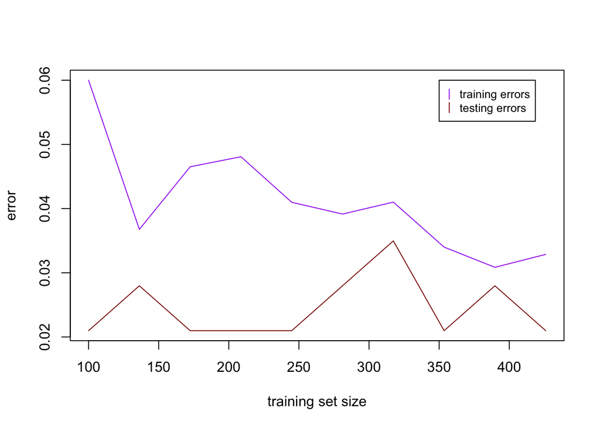

### Additional Logistic Regression Model Assessments

*Function that takes in predicts and actuals to produce a dataframe that contains model-assessing information, using different thresholds.*

```r
> prec_recall_summary = function(predicts, actuals) {
+    thresh = seq(0, 1, length.out=50)
+    prec_rec = data.frame()
+    actuals = factor(as.numeric(actuals))
+    for (th in thresh) {
+      predicts = factor(as.numeric(pred >= th), levels=c("0","1"))
+      prec_rec = rbind(prec_rec, as.vector(table(predicts, actuals)))
+    }
+    names(prec_rec) = c("TN", "FP", "FN", "TP")
+    prec_rec$threshold = thresh
+    prec_rec$precision = prec_rec$TP/(prec_rec$TP + prec_rec$FP)
+    prec_rec$recall    = prec_rec$TP/(prec_rec$TP + prec_rec$FN)
+    prec_rec$false_pos = prec_rec$FP/(prec_rec$FP + prec_rec$TN)
+    return(prec_rec)
+  }
>  prec_rec = prec_recall_summary(predicts, actuals)
```

#### Plots show precision and recall for Logistic Regression

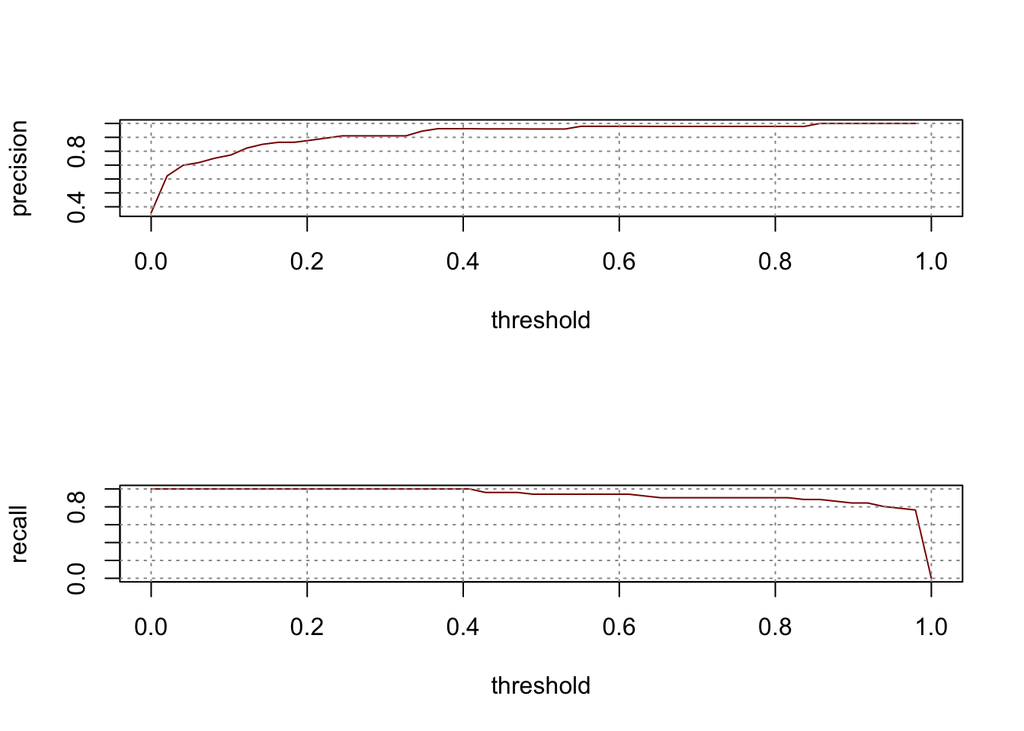

```r
> par(mfrow=c(2,1))
> plot(prec_rec$threshold, prec_rec$precision, col = "red4", type = "l", xlab = "threshold", ylab = "precision" )
> grid(col="grey60")
> plot(prec_rec$threshold, prec_rec$recall, col = "red4", type = "l", xlab = "threshold", ylab = "recall" )
> grid(col="grey60")
```

#### Receiver Operating Character Graph for Logistic Regrassion

[figure not shown]

```r
> prec_rec$true_pos = prec_rec$TP / (prec_rec$TP + prec_rec$FN)
> plot( prec_rec$false_pos, prec_rec$true_pos, col = "red4", type = "l", xlab = "True positive rate", ylab = "False positive rate" , main= "ROC")
> grid(col="grey60")
```